# PML Course Project

## Predictive Model Training

In this section, three machine learning models will be evaluated: Decision Tree, Random Foreset, and Generalized Boosted Model. Instead of using the caret package wrapper, I am opting to use each of the base machine learning functions. Although we give up a reduction in complexity, the performance (from a speed perspective) seemed much better on the specific system being used.

#### Decision Tree Model

```r
model_tree <- rpart(classe ~ ., data=train, method="class")
pred_tree_train <- predict(model_tree, newdata=train, type="class")
pred_tree_validate <- predict(model_tree, newdata=validate, type="class")
```

Check the confusion matrix for the accurracy of the model against the training data and the validation data.

```r
confusionMatrix(pred_tree_train, train$classe)$overall['Accuracy']
```

```
##  Accuracy
## 0.7480527
```

```r
confusionMatrix(pred_tree_validate, validate$classe)$overall['Accuracy']
```

```
##  Accuracy
## 0.7413764
```

There is only a slight decrease in accuracy when applied to the validation data, so the model seems to perform well in out of sample data.

Pruning the tree may also reduce this error. To do this, first plot the complexity parameters and look for the smallest cross validation error.

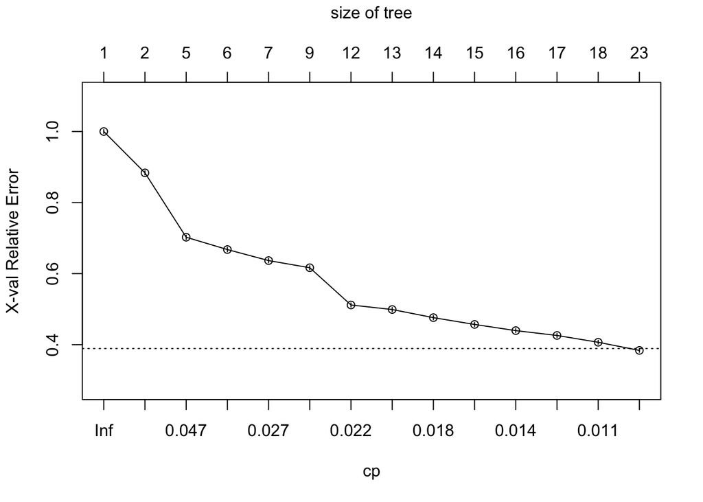

```r
plotcp(model_tree)
```

Given the plot, 0.01 can be used as the complexity parameter. However, pruning the tree doesn’t buy us much in accuracy improvement here.

```r
cp <- 0.01
model_ptree <- prune(model_tree, cp=cp)
pred_ptree <- predict(model_ptree, newdata=validate, type="class")
confusionMatrix(pred_ptree, validate$classe)$overall['Accuracy']
```

```
##  Accuracy
## 0.7413764
```

#### Random Forest Model

```r
model_rf <- randomForest(classe ~ ., data=train)
pred_rf <- predict(model_rf, newdata=train, type="class")
confusionMatrix(pred_rf, train$classe)$overall['Accuracy']
```

```
## Accuracy
##        1
```

```r
pred_rf <- predict(model_rf, newdata=validate, type="class")
confusionMatrix(pred_rf, validate$classe)$overall['Accuracy']
```

```
##  Accuracy
## 0.9950722
```

Comparing the random forest model, it has significantly better accuracy. In fact, it predicted the training data perfectly. It’s also not badly overfitting the training data as it still has stellar accuracy on the validation training set.

#### Generalized Boosted Model

Finally, a GBM model is fit. An additional cross validation with 5 folds is performed in fitting the model to reduce out of sample error. This is also a good example of the reduced complexity benefit you get from caret. By not using the caret wrapper, an apply function needs to be used to get the mostly likely response.

```r
model_gbm <- gbm(classe ~ ., data=train, cv.folds=5, distribution="multinomial")
pred_gbm <- predict(model_gbm, validate, type="response")
```

```
## Using 100 trees...
```

```r
pred_gbm_class <- apply(pred_gbm, 1, which.max)
confusionMatrix(pred_gbm_class, as.numeric(validate$classe))$overall['Accuracy']
```

```
##  Accuracy
## 0.4876805
```

Suprisingly, the accuracy of the GBM model is the lowest of the three selected for this project. If it weren’t for the fact that the random forest model performed with high accuracy, it would make sense to troubleshoot this further and try to tune the training control parameters. Others in the class seemed to get better accuracy through GBM, so it may be caused by avoiding parameters set by caret for GBM.

## Final Prediction for Submission

When first planning this project, I figured I would make use of a stacked model with the best performing 2-3 used to make the final prediction. Given the 99% accuracy of the random forest when used on the validation data set, I opted not to. The final predictions from the random forest model are listed below.

```r
pred_quiz <- predict(model_rf, newdata=test, type="class")
pred_quiz
```

```
##  1  2  3  4  5  6  7  8  9 10 11 12 13 14 15 16 17 18 19 20
##  B  A  B  A  A  E  D  B  A  A  B  C  B  A  E  E  A  B  B  B
## Levels: A B C D E
```

#### Results

This random forest model was able to predict the classe variable of the test data set with 100% accurracy. It turns out that this model did a great job in real life prediction for the Project Quiz.